# CCRCN Synthesis Report

### Introduction

The CCRCN clearinghouse provides a synthesized and curated set of coastal carbon data that promotes the sharing of open data, novel analyses, and collaboration opportunities. The synthesis is created by curating and merging publically available data through an automated script. This report documents the success or failure of the automated synthesis process, documents changes, conducts QA/QC tests, and provides visualizations and summaries of data within the clearinghouse.

#### Report date: 2019/08/12-14:17

#### Synthesis status: Successful

#### Contact: Michael Lonneman (lonnemanM@si.edu)

### Change log

If any study IDs are added or removed to the synthesis, they will be listed below.

#### New studies

|  | study_id | core_id | depth_min | depth_max | dry_bulk_density | fraction_organic_matter | fraction_carbon | sample_id | fraction_carbon_type | c14_age | c14_age_sd | c14_material | age | age_depth_model_reference | site_id | cs137_activity | cs137_unit | cs137_activity_notes | total_pb210_activity | ra226_activity | excess_pb210_activity | pb210_unit | be7_activity | be7_activity_notes | pb214_activity | pb214_unit | bi214_activity | bi214_unit | cs137_activity_sd | … |
| --- | --- | --- | --- | --- | --- | --- | --- | --- | --- | --- | --- | --- | --- | --- | --- | --- | --- | --- | --- | --- | --- | --- | --- | --- | --- | --- | --- | --- | --- | --- |
| 1 | Osland_et_al_2012 | M0334 | 0 | 10 | 0.146666667 | 0.543666667 | 0.2012357839 |  |  |  |  |  |  |  | MJO12 South Cockroach Bay |  |  |  |  |  |  |  |  |  |  |  |  |  |  | … |
| 2 | Osland_et_al_2012 | M0334 | 10 | 30 | 0.2 | 0.487 | 0.2020728175 |  |  |  |  |  |  |  | MJO12 South Cockroach Bay |  |  |  |  |  |  |  |  |  |  |  |  |  |  | … |
| 3 | Osland_et_al_2012 | M0338 | 0 | 10 | 0.443333333 | 0.125 | 0.06730012576 |  |  |  |  |  |  |  | MJO12 Apollo Beach |  |  |  |  |  |  |  |  |  |  |  |  |  |  | … |
| 4 | Osland_et_al_2012 | M0338 | 10 | 30 | 0.76 | 0.057333333 | 0.03329393705 |  |  |  |  |  |  |  | MJO12 Apollo Beach |  |  |  |  |  |  |  |  |  |  |  |  |  |  | … |
| 5 | Cifuentes_Unpublished | M0760 | 0 | 15 | 0.52 |  | 0.0668 |  |  |  |  |  |  |  | MCU Térraba25 |  |  |  |  |  |  |  |  |  |  |  |  |  |  | … |
| 6 | Cifuentes_Unpublished | M0760 | 15 | 30 | 0.45 |  | 0.0866 |  |  |  |  |  |  |  | MCU Térraba25 |  |  |  |  |  |  |  |  |  |  |  |  |  |  | … |
| 7 | Cifuentes_Unpublished | M0760 | 30 | 50 | 0.44 |  | 0.0954 |  |  |  |  |  |  |  | MCU Térraba25 |  |  |  |  |  |  |  |  |  |  |  |  |  |  | … |
| 8 | Cifuentes_Unpublished | M0760 | 50 | 100 | 0.47 |  | 0.0832 |  |  |  |  |  |  |  | MCU Térraba25 |  |  |  |  |  |  |  |  |  |  |  |  |  |  | … |
| 9 | Cifuentes_Unpublished | M0761 | 0 | 15 | 0.69 |  | 0.0255 |  |  |  |  |  |  |  | MCU Térraba26 |  |  |  |  |  |  |  |  |  |  |  |  |  |  | … |
| 10 | Cifuentes_Unpublished | M0761 | 15 | 30 | 0.67 |  | 0.0264 |  |  |  |  |  |  |  | MCU Térraba26 |  |  |  |  |  |  |  |  |  |  |  |  |  |  | … |

[output cut: 39 more lines]

#### Studies removed from the synthesis

```
## [1] "No studies were removed from the synthesis"
```

### QA/QC Test Results

|  | Test | Result |
| --- | --- | --- |
| 1 | Core ID uniqueness | Passed |
| 2 | Valid core ID links in depthseries table | Passed |
| 3 | Valid core ID links in core table | Passed |
| 4 | Test coordinate uniqueness | 630 sets of coordinates are associated with more than one core. Check 'data/QA/duplicate_coordinates.csv' |
| 5 | Validity of column names in methods table | Undefined columns: publication_type, fraction_carbon_flag |
| 6 | Validity of column names in impacts table | Passed |
| 7 | Validity of column names in species table | Passed |
| 8 | Validity of column names in sites table | Passed |
| 9 | Validity of column names in cores table | Passed |
| 10 | Validity of column names in depthseries table | Undefined columns: cs137_peak_present, cs137_activity_notes, be7_activity_notes, bi214_activity, bi214_unit, total_pb210_sd, fraction_carbon_type, age_depth_model_reference |

[output cut: 5 more lines]

### Numeric Attribute Summary Statistics

|  | variable | type | n | min | max | median | mean | sd | missing | na_count | NaN_count |
| --- | --- | --- | --- | --- | --- | --- | --- | --- | --- | --- | --- |
| 1 | age | numeric | 33237 | -47 | 5818 | 1903 | 1316.48 | 1086.41 | 32170 | 32170 | 0 |
| 2 | age_max | numeric | 33237 | -19 | 4432 | 842 | 1171.03 | 1116.39 | 33080 | 33080 | 0 |
| 3 | age_min | numeric | 33237 | -61 | 3972 | 579 | 890.61 | 949.29 | 33080 | 33080 | 0 |
| 4 | age_sd | numeric | 33237 | 0 | 155 | 0.7 | 5.71 | 17.75 | 33038 | 33038 | 0 |
| 5 | be7_activity | numeric | 33237 | 0 | 12.54 | 0 | 0.19 | 1.19 | 32865 | 32865 | 0 |
| 6 | c14_age | numeric | 33237 | 30 | 5085 | 2030 | 2350.52 | 1651.23 | 33160 | 33160 | 0 |
| 7 | c14_age_sd | numeric | 33237 | 30 | 60 | 30 | 33.57 | 5.73 | 33160 | 33160 | 0 |
| 8 | compaction_fraction | numeric | 33237 | 0.37 | 0.45 | 0.39 | 0.39 | 0.028 | 33045 | 33045 | 0 |
| 9 | cs137_activity | numeric | 33237 | -0.14 | 11278 | 0.15 | 124.37 | 530.73 | 32453 | 32453 | 0 |
| 10 | cs137_activity_sd | numeric | 33237 | 0.012 | 0.34 | 0.078 | 0.09 | 0.058 | 32984 | 32984 | 0 |

[output cut: 13 more lines]

### Depthseries Visualization

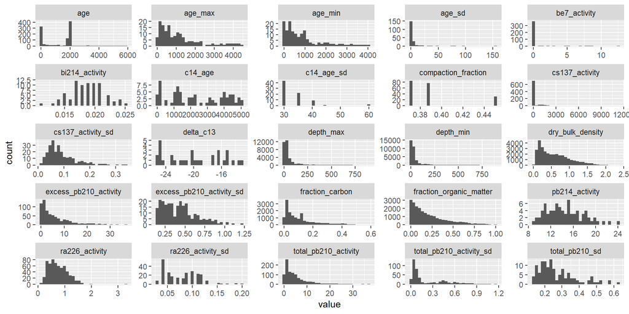

### Change log results

The following table summarizes which entries across the range of synthesis tables changed compared to the previous synthesis. Study IDs associated with the “forward” change type represent data that was not present in the previous synthesis, while “backward” indicates that study ID is no longer in the given table. If a study ID in a table is associated with both backward and forward change types, it is likely that one or more values were altered for that row in the new synthesis.

|  | table | change_types | study_id |
| --- | --- | --- | --- |
| 1 | depthseries | forward, backward | Cifuentes_Unpublished |
| 2 | depthseries | forward, backward | Osland_et_al_2012 |
| 3 | cores | forward | Cifuentes_Unpublished |
| 4 | cores | forward | Osland_et_al_2012 |
| 5 | species | forward, backward |  |
| 6 | species | forward, backward | Calleja_et_al_2007 |
| 7 | species | forward, backward | Cifuentes_Unpublished |
| 8 | species | forward, backward | Ferreira_et_al_2007 |
| 9 | species | forward, backward | Gonneea_et_al_2004 |
| 10 | species | forward | Krauss_et_al_2018a |

[output cut: 106 more lines]